# Risk Factor Analysis

## Outcome Variable

**Outcome Variable:** ever_co

## Predictor Variables

**Intervention Variable:** impfloor

**Adjustment Set:**

- arm
- sex
- W_mage
- meducyrs
- feducyrs
- hhwealth_quart
- hfoodsec
- W_mhtcm
- W_mwtkg
- W_mbmi
- W_nrooms
- W_nchldlt5
- W_parity
- impsan
- safeh20
- delta_W_mage
- delta_meducyrs
- delta_feducyrs
- delta_hhwealth_quart
- delta_hfoodsec
- delta_W_mhtcm
- delta_W_mwtkg
- delta_W_mbmi
- delta_W_nrooms
- delta_W_nchldlt5
- delta_W_parity
- delta_impsan
- delta_safeh20

## Stratifying Variables

The analysis was stratified on these variable(s):

- agecat
- studyid
- country

## Data Summary

| agecat | studyid | country | impfloor | ever_co | n_cell | n |
| --- | --- | --- | --- | --- | --- | --- |
| 0-24 months | ki0047075b-MAL-ED | BANGLADESH | 1 | 0 | 189 | 242 |
| 0-24 months | ki0047075b-MAL-ED | BANGLADESH | 1 | 1 | 34 | 242 |
| 0-24 months | ki0047075b-MAL-ED | BANGLADESH | 0 | 0 | 14 | 242 |
| 0-24 months | ki0047075b-MAL-ED | BANGLADESH | 0 | 1 | 5 | 242 |
| 0-24 months | ki0047075b-MAL-ED | BRAZIL | 1 | 0 | 205 | 210 |
| 0-24 months | ki0047075b-MAL-ED | BRAZIL | 1 | 1 | 3 | 210 |
| 0-24 months | ki0047075b-MAL-ED | BRAZIL | 0 | 0 | 2 | 210 |
| 0-24 months | ki0047075b-MAL-ED | BRAZIL | 0 | 1 | 0 | 210 |
| 0-24 months | ki0047075b-MAL-ED | INDIA | 1 | 0 | 173 | 235 |
| 0-24 months | ki0047075b-MAL-ED | INDIA | 1 | 1 | 47 | 235 |
| 0-24 months | ki0047075b-MAL-ED | INDIA | 0 | 0 | 9 | 235 |
| 0-24 months | ki0047075b-MAL-ED | INDIA | 0 | 1 | 6 | 235 |
| 0-24 months | ki0047075b-MAL-ED | NEPAL | 1 | 0 | 93 | 229 |
| 0-24 months | ki0047075b-MAL-ED | NEPAL | 1 | 1 | 10 | 229 |
| 0-24 months | ki0047075b-MAL-ED | NEPAL | 0 | 0 | 116 | 229 |
| 0-24 months | ki0047075b-MAL-ED | NEPAL | 0 | 1 | 10 | 229 |
| 0-24 months | ki0047075b-MAL-ED | PERU | 1 | 0 | 55 | 272 |
| 0-24 months | ki0047075b-MAL-ED | PERU | 1 | 1 | 4 | 272 |
| 0-24 months | ki0047075b-MAL-ED | PERU | 0 | 0 | 206 | 272 |
| 0-24 months | ki0047075b-MAL-ED | PERU | 0 | 1 | 7 | 272 |
| 0-24 months | ki0047075b-MAL-ED | SOUTH AFRICA | 1 | 0 | 214 | 257 |
| 0-24 months | ki0047075b-MAL-ED | SOUTH AFRICA | 1 | 1 | 22 | 257 |
| 0-24 months | ki0047075b-MAL-ED | SOUTH AFRICA | 0 | 0 | 21 | 257 |
| 0-24 months | ki0047075b-MAL-ED | SOUTH AFRICA | 0 | 1 | 0 | 257 |
| 0-24 months | ki0047075b-MAL-ED | TANZANIA, UNITED REPUBLIC OF | 1 | 0 | 14 | 248 |
| 0-24 months | ki0047075b-MAL-ED | TANZANIA, UNITED REPUBLIC OF | 1 | 1 | 0 | 248 |
| 0-24 months | ki0047075b-MAL-ED | TANZANIA, UNITED REPUBLIC OF | 0 | 0 | 211 | 248 |
| 0-24 months | ki0047075b-MAL-ED | TANZANIA, UNITED REPUBLIC OF | 0 | 1 | 23 | 248 |
| 0-24 months | ki1000108-CMC-V-BCS-2002 | INDIA | 1 | 0 | 198 | 261 |
| 0-24 months | ki1000108-CMC-V-BCS-2002 | INDIA | 1 | 1 | 63 | 261 |

[output cut: 162 more lines]

The following strata were considered:

- agecat: 0-24 months, studyid: ki0047075b-MAL-ED, country: BANGLADESH
- agecat: 0-24 months, studyid: ki0047075b-MAL-ED, country: BRAZIL
- agecat: 0-24 months, studyid: ki0047075b-MAL-ED, country: INDIA
- agecat: 0-24 months, studyid: ki0047075b-MAL-ED, country: NEPAL
- agecat: 0-24 months, studyid: ki0047075b-MAL-ED, country: PERU
- agecat: 0-24 months, studyid: ki0047075b-MAL-ED, country: SOUTH AFRICA
- agecat: 0-24 months, studyid: ki0047075b-MAL-ED, country: TANZANIA, UNITED REPUBLIC OF
- agecat: 0-24 months, studyid: ki1000108-CMC-V-BCS-2002, country: INDIA
- agecat: 0-24 months, studyid: ki1000108-IRC, country: INDIA
- agecat: 0-24 months, studyid: ki1017093-NIH-Birth, country: BANGLADESH
- agecat: 0-24 months, studyid: ki1017093b-PROVIDE, country: BANGLADESH
- agecat: 0-24 months, studyid: ki1017093c-NIH-Crypto, country: BANGLADESH
- agecat: 0-24 months, studyid: ki1113344-GMS-Nepal, country: NEPAL
- agecat: 0-24 months, studyid: ki1114097-CONTENT, country: PERU
- agecat: 0-24 months, studyid: kiGH5241-JiVitA-3, country: BANGLADESH
- agecat: 0-24 months, studyid: kiGH5241-JiVitA-4, country: BANGLADESH
- agecat: 0-6 months, studyid: ki0047075b-MAL-ED, country: BANGLADESH
- agecat: 0-6 months, studyid: ki0047075b-MAL-ED, country: BRAZIL
- agecat: 0-6 months, studyid: ki0047075b-MAL-ED, country: INDIA
- agecat: 0-6 months, studyid: ki0047075b-MAL-ED, country: NEPAL
- agecat: 0-6 months, studyid: ki0047075b-MAL-ED, country: PERU
- agecat: 0-6 months, studyid: ki0047075b-MAL-ED, country: SOUTH AFRICA
- agecat: 0-6 months, studyid: ki0047075b-MAL-ED, country: TANZANIA, UNITED REPUBLIC OF
- agecat: 0-6 months, studyid: ki1000108-CMC-V-BCS-2002, country: INDIA
- agecat: 0-6 months, studyid: ki1000108-IRC, country: INDIA
- agecat: 0-6 months, studyid: ki1017093-NIH-Birth, country: BANGLADESH
- agecat: 0-6 months, studyid: ki1017093b-PROVIDE, country: BANGLADESH
- agecat: 0-6 months, studyid: ki1017093c-NIH-Crypto, country: BANGLADESH
- agecat: 0-6 months, studyid: ki1113344-GMS-Nepal, country: NEPAL
- agecat: 0-6 months, studyid: ki1114097-CONTENT, country: PERU
- agecat: 0-6 months, studyid: kiGH5241-JiVitA-3, country: BANGLADESH
- agecat: 0-6 months, studyid: kiGH5241-JiVitA-4, country: BANGLADESH
- agecat: 6-24 months, studyid: ki0047075b-MAL-ED, country: BANGLADESH
- agecat: 6-24 months, studyid: ki0047075b-MAL-ED, country: BRAZIL
- agecat: 6-24 months, studyid: ki0047075b-MAL-ED, country: INDIA
- agecat: 6-24 months, studyid: ki0047075b-MAL-ED, country: NEPAL
- agecat: 6-24 months, studyid: ki0047075b-MAL-ED, country: PERU
- agecat: 6-24 months, studyid: ki0047075b-MAL-ED, country: SOUTH AFRICA
- agecat: 6-24 months, studyid: ki0047075b-MAL-ED, country: TANZANIA, UNITED REPUBLIC OF
- agecat: 6-24 months, studyid: ki1000108-CMC-V-BCS-2002, country: INDIA
- agecat: 6-24 months, studyid: ki1000108-IRC, country: INDIA
- agecat: 6-24 months, studyid: ki1017093-NIH-Birth, country: BANGLADESH
- agecat: 6-24 months, studyid: ki1017093b-PROVIDE, country: BANGLADESH
- agecat: 6-24 months, studyid: ki1017093c-NIH-Crypto, country: BANGLADESH
- agecat: 6-24 months, studyid: ki1113344-GMS-Nepal, country: NEPAL
- agecat: 6-24 months, studyid: ki1114097-CONTENT, country: PERU
- agecat: 6-24 months, studyid: kiGH5241-JiVitA-3, country: BANGLADESH
- agecat: 6-24 months, studyid: kiGH5241-JiVitA-4, country: BANGLADESH

### Dropped Strata

Some strata were dropped due to rare outcomes:

- agecat: 0-24 months, studyid: ki0047075b-MAL-ED, country: BRAZIL
- agecat: 0-24 months, studyid: ki0047075b-MAL-ED, country: PERU
- agecat: 0-24 months, studyid: ki0047075b-MAL-ED, country: SOUTH AFRICA
- agecat: 0-24 months, studyid: ki0047075b-MAL-ED, country: TANZANIA, UNITED REPUBLIC OF
- agecat: 0-24 months, studyid: ki1000108-CMC-V-BCS-2002, country: INDIA
- agecat: 0-24 months, studyid: ki1000108-IRC, country: INDIA
- agecat: 0-24 months, studyid: ki1114097-CONTENT, country: PERU
- agecat: 0-6 months, studyid: ki0047075b-MAL-ED, country: BANGLADESH
- agecat: 0-6 months, studyid: ki0047075b-MAL-ED, country: BRAZIL
- agecat: 0-6 months, studyid: ki0047075b-MAL-ED, country: INDIA
- agecat: 0-6 months, studyid: ki0047075b-MAL-ED, country: NEPAL
- agecat: 0-6 months, studyid: ki0047075b-MAL-ED, country: PERU
- agecat: 0-6 months, studyid: ki0047075b-MAL-ED, country: SOUTH AFRICA
- agecat: 0-6 months, studyid: ki0047075b-MAL-ED, country: TANZANIA, UNITED REPUBLIC OF
- agecat: 0-6 months, studyid: ki1000108-CMC-V-BCS-2002, country: INDIA
- agecat: 0-6 months, studyid: ki1000108-IRC, country: INDIA
- agecat: 0-6 months, studyid: ki1017093c-NIH-Crypto, country: BANGLADESH
- agecat: 0-6 months, studyid: ki1114097-CONTENT, country: PERU
- agecat: 6-24 months, studyid: ki0047075b-MAL-ED, country: BANGLADESH
- agecat: 6-24 months, studyid: ki0047075b-MAL-ED, country: BRAZIL
- agecat: 6-24 months, studyid: ki0047075b-MAL-ED, country: PERU
- agecat: 6-24 months, studyid: ki0047075b-MAL-ED, country: SOUTH AFRICA
- agecat: 6-24 months, studyid: ki0047075b-MAL-ED, country: TANZANIA, UNITED REPUBLIC OF
- agecat: 6-24 months, studyid: ki1000108-CMC-V-BCS-2002, country: INDIA
- agecat: 6-24 months, studyid: ki1000108-IRC, country: INDIA
- agecat: 6-24 months, studyid: ki1114097-CONTENT, country: PERU

## Methods Detail

We’re interested in the causal parameters $E[Y_a]$ for all values of $a \in \mathcal{A}$. These parameters represent the mean outcome if, possibly contrary to fact, we intervened to set all units to have $A=a$. Under the randomization and positivity assumptions, these are identified by the statistical parameters $\psi_a=E_W[E_{Y|A,W}(Y|A=a,W)]$. In addition, we’re interested in the mean of $Y$, $E[Y]$ under no intervention (the observed mean). We will estimate these parameters by using SuperLearner to fit the relevant likelihood factors – $E_{Y|A,W}(Y|A=a,W)$ and $p(A=a|W)$, and then updating our likelihood fit using a joint TMLE.

For unadjusted analyses ($W=\{\}$), initial likelihoods were estimated using Lrnr_glm to estimate the simple $E(Y|A)$ and Lrnr_mean to estimate $p(A)$. For adjusted analyses, a small library containing Lrnr_glmnet, Lrnr_xgboost, and Lrnr_mean was used.

Having estimated these parameters, we will then use the delta method to estimate relative risks and attributable risks relative to a prespecified baseline level of $A$.

# Results Detail

## Results Plots

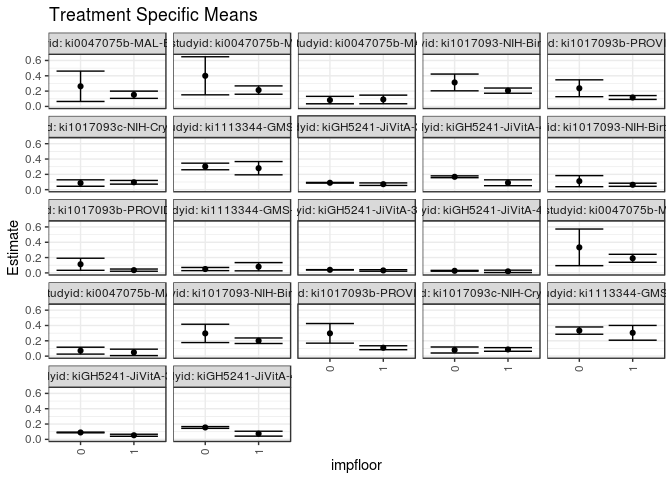

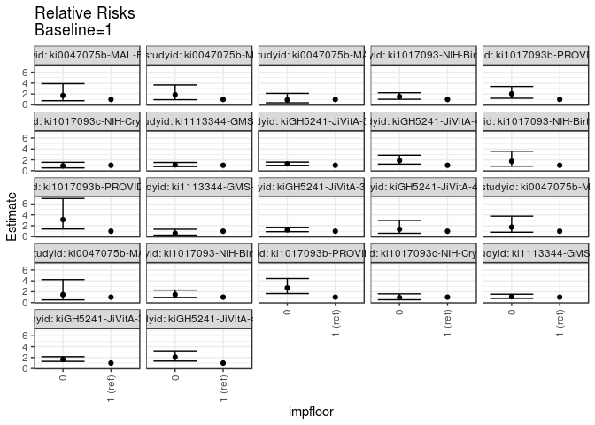

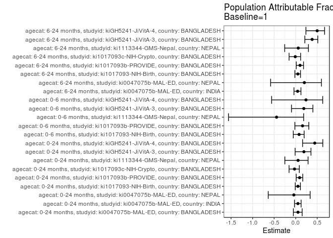

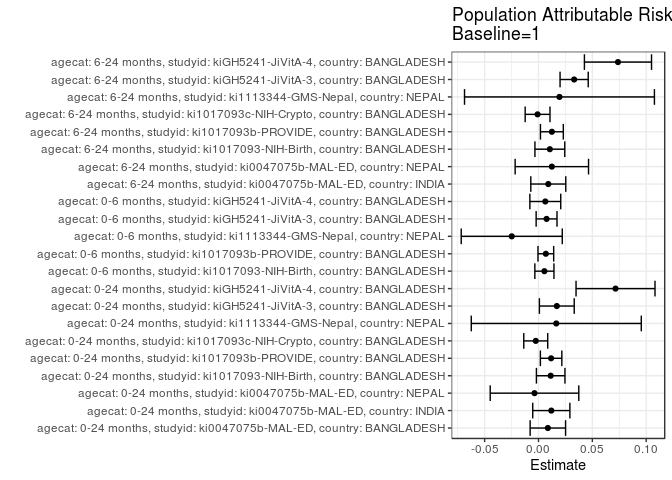

## Results Table

### Parameter: TSM

| agecat | studyid | country | intervention_level | baseline_level | estimate | ci_lower | ci_upper |
| --- | --- | --- | --- | --- | --- | --- | --- |
| 0-24 months | ki0047075b-MAL-ED | BANGLADESH | 1 | NA | 0.1524664 | 0.1051882 | 0.1997445 |
| 0-24 months | ki0047075b-MAL-ED | BANGLADESH | 0 | NA | 0.2631579 | 0.0647468 | 0.4615690 |
| 0-24 months | ki0047075b-MAL-ED | INDIA | 1 | NA | 0.2136364 | 0.1593598 | 0.2679129 |
| 0-24 months | ki0047075b-MAL-ED | INDIA | 0 | NA | 0.4000000 | 0.1515528 | 0.6484472 |
| 0-24 months | ki0047075b-MAL-ED | NEPAL | 1 | NA | 0.0910552 | 0.0345931 | 0.1475173 |
| 0-24 months | ki0047075b-MAL-ED | NEPAL | 0 | NA | 0.0829851 | 0.0344773 | 0.1314929 |
| 0-24 months | ki1017093-NIH-Birth | BANGLADESH | 1 | NA | 0.2060788 | 0.1721700 | 0.2399877 |
| 0-24 months | ki1017093-NIH-Birth | BANGLADESH | 0 | NA | 0.3132433 | 0.2039045 | 0.4225820 |
| 0-24 months | ki1017093b-PROVIDE | BANGLADESH | 1 | NA | 0.1168581 | 0.0918946 | 0.1418216 |
| 0-24 months | ki1017093b-PROVIDE | BANGLADESH | 0 | NA | 0.2371862 | 0.1268264 | 0.3475461 |
| 0-24 months | ki1017093c-NIH-Crypto | BANGLADESH | 1 | NA | 0.0962307 | 0.0721892 | 0.1202722 |
| 0-24 months | ki1017093c-NIH-Crypto | BANGLADESH | 0 | NA | 0.0863313 | 0.0444103 | 0.1282523 |
| 0-24 months | ki1113344-GMS-Nepal | NEPAL | 1 | NA | 0.2801283 | 0.1933734 | 0.3668832 |
| 0-24 months | ki1113344-GMS-Nepal | NEPAL | 0 | NA | 0.3028257 | 0.2596822 | 0.3459692 |
| 0-24 months | kiGH5241-JiVitA-3 | BANGLADESH | 1 | NA | 0.0717392 | 0.0550890 | 0.0883893 |
| 0-24 months | kiGH5241-JiVitA-3 | BANGLADESH | 0 | NA | 0.0899543 | 0.0859222 | 0.0939864 |
| 0-24 months | kiGH5241-JiVitA-4 | BANGLADESH | 1 | NA | 0.0899577 | 0.0518240 | 0.1280915 |
| 0-24 months | kiGH5241-JiVitA-4 | BANGLADESH | 0 | NA | 0.1680499 | 0.1560300 | 0.1800698 |
| 0-6 months | ki1017093-NIH-Birth | BANGLADESH | 1 | NA | 0.0639854 | 0.0434602 | 0.0845106 |
| 0-6 months | ki1017093-NIH-Birth | BANGLADESH | 0 | NA | 0.1111111 | 0.0384611 | 0.1837611 |
| 0-6 months | ki1017093b-PROVIDE | BANGLADESH | 1 | NA | 0.0360502 | 0.0215748 | 0.0505255 |
| 0-6 months | ki1017093b-PROVIDE | BANGLADESH | 0 | NA | 0.1129032 | 0.0340714 | 0.1917350 |
| 0-6 months | ki1113344-GMS-Nepal | NEPAL | 1 | NA | 0.0808081 | 0.0270719 | 0.1345442 |
| 0-6 months | ki1113344-GMS-Nepal | NEPAL | 0 | NA | 0.0503432 | 0.0298237 | 0.0708628 |
| 0-6 months | kiGH5241-JiVitA-3 | BANGLADESH | 1 | NA | 0.0321324 | 0.0222393 | 0.0420255 |
| 0-6 months | kiGH5241-JiVitA-3 | BANGLADESH | 0 | NA | 0.0401992 | 0.0375882 | 0.0428103 |
| 0-6 months | kiGH5241-JiVitA-4 | BANGLADESH | 1 | NA | 0.0200650 | 0.0047061 | 0.0354240 |
| 0-6 months | kiGH5241-JiVitA-4 | BANGLADESH | 0 | NA | 0.0272783 | 0.0216297 | 0.0329268 |
| 6-24 months | ki0047075b-MAL-ED | INDIA | 1 | NA | 0.1909091 | 0.1388646 | 0.2429536 |
| 6-24 months | ki0047075b-MAL-ED | INDIA | 0 | NA | 0.3333333 | 0.0942649 | 0.5724018 |
| 6-24 months | ki0047075b-MAL-ED | NEPAL | 1 | NA | 0.0490196 | 0.0070270 | 0.0910123 |
| 6-24 months | ki0047075b-MAL-ED | NEPAL | 0 | NA | 0.0714286 | 0.0263613 | 0.1164958 |
| 6-24 months | ki1017093-NIH-Birth | BANGLADESH | 1 | NA | 0.2009641 | 0.1649854 | 0.2369429 |
| 6-24 months | ki1017093-NIH-Birth | BANGLADESH | 0 | NA | 0.2968267 | 0.1771478 | 0.4165055 |
| 6-24 months | ki1017093b-PROVIDE | BANGLADESH | 1 | NA | 0.1097258 | 0.0839274 | 0.1355242 |
| 6-24 months | ki1017093b-PROVIDE | BANGLADESH | 0 | NA | 0.2973596 | 0.1691358 | 0.4255834 |
| 6-24 months | ki1017093c-NIH-Crypto | BANGLADESH | 1 | NA | 0.0871616 | 0.0635769 | 0.1107462 |
| 6-24 months | ki1017093c-NIH-Crypto | BANGLADESH | 0 | NA | 0.0799990 | 0.0407460 | 0.1192521 |
| 6-24 months | ki1113344-GMS-Nepal | NEPAL | 1 | NA | 0.3045020 | 0.2081008 | 0.4009031 |
| 6-24 months | ki1113344-GMS-Nepal | NEPAL | 0 | NA | 0.3335342 | 0.2861249 | 0.3809435 |
| 6-24 months | kiGH5241-JiVitA-3 | BANGLADESH | 1 | NA | 0.0535625 | 0.0403861 | 0.0667389 |
| 6-24 months | kiGH5241-JiVitA-3 | BANGLADESH | 0 | NA | 0.0900054 | 0.0850925 | 0.0949183 |
| 6-24 months | kiGH5241-JiVitA-4 | BANGLADESH | 1 | NA | 0.0739711 | 0.0420488 | 0.1058934 |
| 6-24 months | kiGH5241-JiVitA-4 | BANGLADESH | 0 | NA | 0.1555641 | 0.1440575 | 0.1670706 |

### Parameter: E(Y)

| agecat | studyid | country | intervention_level | baseline_level | estimate | ci_lower | ci_upper |
| --- | --- | --- | --- | --- | --- | --- | --- |
| 0-24 months | ki0047075b-MAL-ED | BANGLADESH | NA | NA | 0.1611570 | 0.1147371 | 0.2075770 |
| 0-24 months | ki0047075b-MAL-ED | INDIA | NA | NA | 0.2255319 | 0.1719836 | 0.2790802 |
| 0-24 months | ki0047075b-MAL-ED | NEPAL | NA | NA | 0.0873362 | 0.0506897 | 0.1239828 |
| 0-24 months | ki1017093-NIH-Birth | BANGLADESH | NA | NA | 0.2173913 | 0.1849240 | 0.2498586 |
| 0-24 months | ki1017093b-PROVIDE | BANGLADESH | NA | NA | 0.1285714 | 0.1037574 | 0.1533855 |
| 0-24 months | ki1017093c-NIH-Crypto | BANGLADESH | NA | NA | 0.0936675 | 0.0729118 | 0.1144233 |
| 0-24 months | ki1113344-GMS-Nepal | NEPAL | NA | NA | 0.2966418 | 0.2579360 | 0.3353476 |
| 0-24 months | kiGH5241-JiVitA-3 | BANGLADESH | NA | NA | 0.0887391 | 0.0848621 | 0.0926161 |
| 0-24 months | kiGH5241-JiVitA-4 | BANGLADESH | NA | NA | 0.1614747 | 0.1501435 | 0.1728058 |
| 0-6 months | ki1017093-NIH-Birth | BANGLADESH | NA | NA | 0.0694669 | 0.0494218 | 0.0895120 |
| 0-6 months | ki1017093b-PROVIDE | BANGLADESH | NA | NA | 0.0428571 | 0.0278427 | 0.0578716 |
| 0-6 months | ki1113344-GMS-Nepal | NEPAL | NA | NA | 0.0559701 | 0.0364922 | 0.0754481 |
| 0-6 months | kiGH5241-JiVitA-3 | BANGLADESH | NA | NA | 0.0396306 | 0.0371318 | 0.0421294 |
| 0-6 months | kiGH5241-JiVitA-4 | BANGLADESH | NA | NA | 0.0263831 | 0.0210411 | 0.0317252 |
| 6-24 months | ki0047075b-MAL-ED | INDIA | NA | NA | 0.2000000 | 0.1487493 | 0.2512507 |
| 6-24 months | ki0047075b-MAL-ED | NEPAL | NA | NA | 0.0614035 | 0.0301736 | 0.0926335 |
| 6-24 months | ki1017093-NIH-Birth | BANGLADESH | NA | NA | 0.2115028 | 0.1769952 | 0.2460104 |
| 6-24 months | ki1017093b-PROVIDE | BANGLADESH | NA | NA | 0.1221498 | 0.0962275 | 0.1480722 |
| 6-24 months | ki1017093c-NIH-Crypto | BANGLADESH | NA | NA | 0.0863014 | 0.0659171 | 0.1066856 |
| 6-24 months | ki1113344-GMS-Nepal | NEPAL | NA | NA | 0.3239741 | 0.2813000 | 0.3666481 |
| 6-24 months | kiGH5241-JiVitA-3 | BANGLADESH | NA | NA | 0.0866539 | 0.0820272 | 0.0912806 |
| 6-24 months | kiGH5241-JiVitA-4 | BANGLADESH | NA | NA | 0.1477587 | 0.1371623 | 0.1583552 |

### Parameter: RR

| agecat | studyid | country | intervention_level | baseline_level | estimate | ci_lower | ci_upper |
| --- | --- | --- | --- | --- | --- | --- | --- |
| 0-24 months | ki0047075b-MAL-ED | BANGLADESH | 1 | 1 | 1.0000000 | 1.0000000 | 1.000000 |
| 0-24 months | ki0047075b-MAL-ED | BANGLADESH | 0 | 1 | 1.7260062 | 0.7638160 | 3.900281 |
| 0-24 months | ki0047075b-MAL-ED | INDIA | 1 | 1 | 1.0000000 | 1.0000000 | 1.000000 |
| 0-24 months | ki0047075b-MAL-ED | INDIA | 0 | 1 | 1.8723404 | 0.9570686 | 3.662913 |
| 0-24 months | ki0047075b-MAL-ED | NEPAL | 1 | 1 | 1.0000000 | 1.0000000 | 1.000000 |
| 0-24 months | ki0047075b-MAL-ED | NEPAL | 0 | 1 | 0.9113715 | 0.3921508 | 2.118057 |
| 0-24 months | ki1017093-NIH-Birth | BANGLADESH | 1 | 1 | 1.0000000 | 1.0000000 | 1.000000 |
| 0-24 months | ki1017093-NIH-Birth | BANGLADESH | 0 | 1 | 1.5200165 | 1.0340220 | 2.234431 |
| 0-24 months | ki1017093b-PROVIDE | BANGLADESH | 1 | 1 | 1.0000000 | 1.0000000 | 1.000000 |
| 0-24 months | ki1017093b-PROVIDE | BANGLADESH | 0 | 1 | 2.0296949 | 1.2172644 | 3.384360 |
| 0-24 months | ki1017093c-NIH-Crypto | BANGLADESH | 1 | 1 | 1.0000000 | 1.0000000 | 1.000000 |
| 0-24 months | ki1017093c-NIH-Crypto | BANGLADESH | 0 | 1 | 0.8971284 | 0.5198829 | 1.548117 |
| 0-24 months | ki1113344-GMS-Nepal | NEPAL | 1 | 1 | 1.0000000 | 1.0000000 | 1.000000 |
| 0-24 months | ki1113344-GMS-Nepal | NEPAL | 0 | 1 | 1.0810252 | 0.7698696 | 1.517939 |
| 0-24 months | kiGH5241-JiVitA-3 | BANGLADESH | 1 | 1 | 1.0000000 | 1.0000000 | 1.000000 |
| 0-24 months | kiGH5241-JiVitA-3 | BANGLADESH | 0 | 1 | 1.2539080 | 0.9926410 | 1.583942 |
| 0-24 months | kiGH5241-JiVitA-4 | BANGLADESH | 1 | 1 | 1.0000000 | 1.0000000 | 1.000000 |
| 0-24 months | kiGH5241-JiVitA-4 | BANGLADESH | 0 | 1 | 1.8680983 | 1.2204745 | 2.859373 |
| 0-6 months | ki1017093-NIH-Birth | BANGLADESH | 1 | 1 | 1.0000000 | 1.0000000 | 1.000000 |
| 0-6 months | ki1017093-NIH-Birth | BANGLADESH | 0 | 1 | 1.7365079 | 0.8382638 | 3.597268 |
| 0-6 months | ki1017093b-PROVIDE | BANGLADESH | 1 | 1 | 1.0000000 | 1.0000000 | 1.000000 |
| 0-6 months | ki1017093b-PROVIDE | BANGLADESH | 0 | 1 | 3.1318373 | 1.3995795 | 7.008108 |
| 0-6 months | ki1113344-GMS-Nepal | NEPAL | 1 | 1 | 1.0000000 | 1.0000000 | 1.000000 |
| 0-6 months | ki1113344-GMS-Nepal | NEPAL | 0 | 1 | 0.6229977 | 0.2855976 | 1.358996 |
| 0-6 months | kiGH5241-JiVitA-3 | BANGLADESH | 1 | 1 | 1.0000000 | 1.0000000 | 1.000000 |
| 0-6 months | kiGH5241-JiVitA-3 | BANGLADESH | 0 | 1 | 1.2510499 | 0.9117708 | 1.716578 |
| 0-6 months | kiGH5241-JiVitA-4 | BANGLADESH | 1 | 1 | 1.0000000 | 1.0000000 | 1.000000 |
| 0-6 months | kiGH5241-JiVitA-4 | BANGLADESH | 0 | 1 | 1.3594932 | 0.6165139 | 2.997859 |
| 6-24 months | ki0047075b-MAL-ED | INDIA | 1 | 1 | 1.0000000 | 1.0000000 | 1.000000 |
| 6-24 months | ki0047075b-MAL-ED | INDIA | 0 | 1 | 1.7460317 | 0.8106464 | 3.760736 |
| 6-24 months | ki0047075b-MAL-ED | NEPAL | 1 | 1 | 1.0000000 | 1.0000000 | 1.000000 |
| 6-24 months | ki0047075b-MAL-ED | NEPAL | 0 | 1 | 1.4571428 | 0.5028581 | 4.222395 |
| 6-24 months | ki1017093-NIH-Birth | BANGLADESH | 1 | 1 | 1.0000000 | 1.0000000 | 1.000000 |
| 6-24 months | ki1017093-NIH-Birth | BANGLADESH | 0 | 1 | 1.4770132 | 0.9499841 | 2.296426 |
| 6-24 months | ki1017093b-PROVIDE | BANGLADESH | 1 | 1 | 1.0000000 | 1.0000000 | 1.000000 |
| 6-24 months | ki1017093b-PROVIDE | BANGLADESH | 0 | 1 | 2.7100250 | 1.6581707 | 4.429119 |
| 6-24 months | ki1017093c-NIH-Crypto | BANGLADESH | 1 | 1 | 1.0000000 | 1.0000000 | 1.000000 |
| 6-24 months | ki1017093c-NIH-Crypto | BANGLADESH | 0 | 1 | 0.9178246 | 0.5241856 | 1.607068 |
| 6-24 months | ki1113344-GMS-Nepal | NEPAL | 1 | 1 | 1.0000000 | 1.0000000 | 1.000000 |
| 6-24 months | ki1113344-GMS-Nepal | NEPAL | 0 | 1 | 1.0953434 | 0.7750609 | 1.547978 |
| 6-24 months | kiGH5241-JiVitA-3 | BANGLADESH | 1 | 1 | 1.0000000 | 1.0000000 | 1.000000 |
| 6-24 months | kiGH5241-JiVitA-3 | BANGLADESH | 0 | 1 | 1.6803800 | 1.3054925 | 2.162921 |
| 6-24 months | kiGH5241-JiVitA-4 | BANGLADESH | 1 | 1 | 1.0000000 | 1.0000000 | 1.000000 |
| 6-24 months | kiGH5241-JiVitA-4 | BANGLADESH | 0 | 1 | 2.1030378 | 1.3609808 | 3.249692 |

### Parameter: PAR

| agecat | studyid | country | intervention_level | baseline_level | estimate | ci_lower | ci_upper |
| --- | --- | --- | --- | --- | --- | --- | --- |
| 0-24 months | ki0047075b-MAL-ED | BANGLADESH | 1 | NA | 0.0086907 | -0.0077585 | 0.0251398 |
| 0-24 months | ki0047075b-MAL-ED | INDIA | 1 | NA | 0.0118956 | -0.0053544 | 0.0291455 |
| 0-24 months | ki0047075b-MAL-ED | NEPAL | 1 | NA | -0.0037189 | -0.0448430 | 0.0374051 |
| 0-24 months | ki1017093-NIH-Birth | BANGLADESH | 1 | NA | 0.0113125 | -0.0019376 | 0.0245625 |
| 0-24 months | ki1017093b-PROVIDE | BANGLADESH | 1 | NA | 0.0117134 | 0.0017527 | 0.0216740 |
| 0-24 months | ki1017093c-NIH-Crypto | BANGLADESH | 1 | NA | -0.0025632 | -0.0136775 | 0.0085512 |
| 0-24 months | ki1113344-GMS-Nepal | NEPAL | 1 | NA | 0.0165135 | -0.0624122 | 0.0954392 |
| 0-24 months | kiGH5241-JiVitA-3 | BANGLADESH | 1 | NA | 0.0169999 | 0.0008279 | 0.0331720 |
| 0-24 months | kiGH5241-JiVitA-4 | BANGLADESH | 1 | NA | 0.0715169 | 0.0348613 | 0.1081725 |
| 0-6 months | ki1017093-NIH-Birth | BANGLADESH | 1 | NA | 0.0054815 | -0.0033801 | 0.0143431 |
| 0-6 months | ki1017093b-PROVIDE | BANGLADESH | 1 | NA | 0.0068070 | -0.0004742 | 0.0140882 |
| 0-6 months | ki1113344-GMS-Nepal | NEPAL | 1 | NA | -0.0248379 | -0.0717451 | 0.0220693 |
| 0-6 months | kiGH5241-JiVitA-3 | BANGLADESH | 1 | NA | 0.0074982 | -0.0021892 | 0.0171856 |
| 0-6 months | kiGH5241-JiVitA-4 | BANGLADESH | 1 | NA | 0.0063181 | -0.0080074 | 0.0206436 |
| 6-24 months | ki0047075b-MAL-ED | INDIA | 1 | NA | 0.0090909 | -0.0071508 | 0.0253326 |
| 6-24 months | ki0047075b-MAL-ED | NEPAL | 1 | NA | 0.0123839 | -0.0216885 | 0.0464563 |
| 6-24 months | ki1017093-NIH-Birth | BANGLADESH | 1 | NA | 0.0105386 | -0.0033214 | 0.0243987 |
| 6-24 months | ki1017093b-PROVIDE | BANGLADESH | 1 | NA | 0.0124241 | 0.0018125 | 0.0230356 |
| 6-24 months | ki1017093c-NIH-Crypto | BANGLADESH | 1 | NA | -0.0008602 | -0.0123826 | 0.0106622 |
| 6-24 months | ki1113344-GMS-Nepal | NEPAL | 1 | NA | 0.0194721 | -0.0686830 | 0.1076272 |
| 6-24 months | kiGH5241-JiVitA-3 | BANGLADESH | 1 | NA | 0.0330914 | 0.0200183 | 0.0461645 |
| 6-24 months | kiGH5241-JiVitA-4 | BANGLADESH | 1 | NA | 0.0737876 | 0.0426274 | 0.1049478 |

### Parameter: PAF

| agecat | studyid | country | intervention_level | baseline_level | estimate | ci_lower | ci_upper |
| --- | --- | --- | --- | --- | --- | --- | --- |
| 0-24 months | ki0047075b-MAL-ED | BANGLADESH | 1 | NA | 0.0539266 | -0.0530109 | 0.1500043 |
| 0-24 months | ki0047075b-MAL-ED | INDIA | 1 | NA | 0.0527444 | -0.0264141 | 0.1257982 |
| 0-24 months | ki0047075b-MAL-ED | NEPAL | 1 | NA | -0.0425819 | -0.6368757 | 0.3359441 |
| 0-24 months | ki1017093-NIH-Birth | BANGLADESH | 1 | NA | 0.0520373 | -0.0106737 | 0.1108571 |
| 0-24 months | ki1017093b-PROVIDE | BANGLADESH | 1 | NA | 0.0911039 | 0.0116274 | 0.1641896 |
| 0-24 months | ki1017093c-NIH-Crypto | BANGLADESH | 1 | NA | -0.0273644 | -0.1529703 | 0.0845578 |
| 0-24 months | ki1113344-GMS-Nepal | NEPAL | 1 | NA | 0.0556682 | -0.2514747 | 0.2874306 |
| 0-24 months | kiGH5241-JiVitA-3 | BANGLADESH | 1 | NA | 0.1915722 | -0.0131423 | 0.3549224 |
| 0-24 months | kiGH5241-JiVitA-4 | BANGLADESH | 1 | NA | 0.4428987 | 0.1604760 | 0.6303121 |
| 0-6 months | ki1017093-NIH-Birth | BANGLADESH | 1 | NA | 0.0789082 | -0.0558885 | 0.1964965 |
| 0-6 months | ki1017093b-PROVIDE | BANGLADESH | 1 | NA | 0.1588297 | -0.0189113 | 0.3055651 |
| 0-6 months | ki1113344-GMS-Nepal | NEPAL | 1 | NA | -0.4437710 | -1.5587230 | 0.1853457 |
| 0-6 months | kiGH5241-JiVitA-3 | BANGLADESH | 1 | NA | 0.1892023 | -0.0957413 | 0.4000473 |
| 0-6 months | kiGH5241-JiVitA-4 | BANGLADESH | 1 | NA | 0.2394754 | -0.5588284 | 0.6289536 |
| 6-24 months | ki0047075b-MAL-ED | INDIA | 1 | NA | 0.0454545 | -0.0388318 | 0.1229023 |
| 6-24 months | ki0047075b-MAL-ED | NEPAL | 1 | NA | 0.2016807 | -0.5826684 | 0.5973169 |
| 6-24 months | ki1017093-NIH-Birth | BANGLADESH | 1 | NA | 0.0498274 | -0.0177512 | 0.1129189 |
| 6-24 months | ki1017093b-PROVIDE | BANGLADESH | 1 | NA | 0.1017117 | 0.0127120 | 0.1826884 |
| 6-24 months | ki1017093c-NIH-Crypto | BANGLADESH | 1 | NA | -0.0099676 | -0.1526864 | 0.1150806 |
| 6-24 months | ki1113344-GMS-Nepal | NEPAL | 1 | NA | 0.0601040 | -0.2552155 | 0.2962128 |
| 6-24 months | kiGH5241-JiVitA-3 | BANGLADESH | 1 | NA | 0.3818801 | 0.2132827 | 0.5143463 |
| 6-24 months | kiGH5241-JiVitA-4 | BANGLADESH | 1 | NA | 0.4993790 | 0.2377952 | 0.6711889 |